# Milestone 5

Jenna Moustafa

3/20/2020

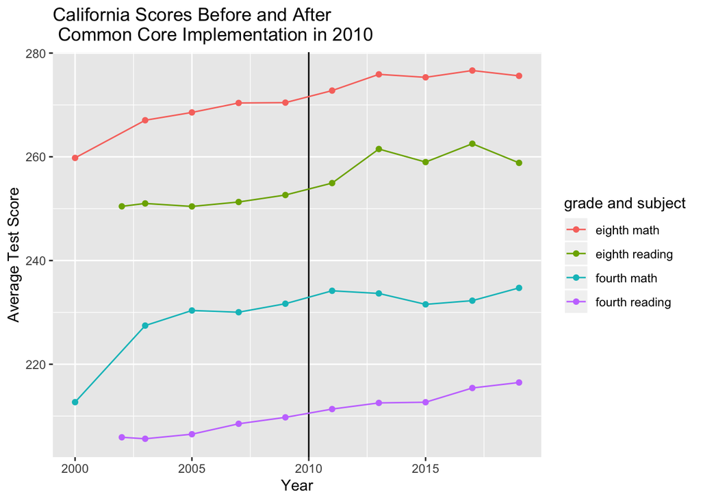

## Background

The goal of this project is to determine how implementation of the common core in California in 2010 affected achievement relative to other states which did not adopt the common core curriculum. The goal of the curriculum standardization is to narrow achievement gaps; however, there is debate over whether the common core actually achieved this goal or states simply adjusted their state standardized tests to allow for teachers’ teaching to the test. To avoid this bias, I am using National Assessment of Educational Progress data which includes average student test scores by states on national standardized exams.

## Data

The data from this project is from nce.ed.gov and nationsreportcard.gov, which has data on test scores by state and year for fourth and eighth grade and yearly high school graduation data respectively. I cleaned all of the data, and combined the test scores for eighth grade reading, eighth grade math, fourth grade reading, and fourth grade math into one table. I might need to gather graduation data for more years before and after implementation of the Common Core for greater robustness.

## Project Plan

The plan for this project is to do an event study design looking at test scores before and after implementation in California relative to the states that did not implement the curriculum as well as graduation data in the years after implementation.